# SOGI IWG: Evaluation of Research to Date (Statistical Topic Modeling)

Pri Oberoi

July 21, 2016

## Introduction

The Federal Interagency Working Group on Measuring Sexual Orientation and Gender Identity is evaluating research done to date by investigating published papers. Members of the IWG are evaluating findings and methods for the papers in this corpus of research. However, our goal here is to use statistical topic modeling to find topics or themes that occur in the corpus for three purposes. First, this provides meta data on each document, since they will be tagged with topics. Second, documents can be clustered together based on what topics they cover and this information can be summarized in a visualization, which can be valuable in a mostly qualitative analysis. Finally, this high-level analysis will allow the members of the working group to see which topics tend to occur together in documents and find any latent topics that might be more pervasive in the corpus than expected.

Topic modeling is a type of statistical model in natural language processing that aims to find topics in a corpus, group topics together by looking for similarity and co-occurence, and categorize documents in the corpus based on the topic probabilities assigned. We are specifically using a statistical method called the latent Dirichlet allocation (LDA). LDA attempts to build topics using the words and documents in the corpus and assumes that each document in the corpus covers one or more of these topics.

## Method

Before running the code below, a script converted the PDFs into text files, this preprocessing code can be examined [here](https://github.com/prioberoi/sogi/blob/master/convert_pdf_to_txt.R). Research papers stored as images were not included in this analysis. Here are a list of the papers included in the model:

```r
#load libraries
library(tm)
```

```r
library(SnowballC)
library(topicmodels)
library(DT)
library(wordcloud)
library(RColorBrewer)
library(reshape2)
library(plyr)
library(ggplot2)
library(plotly)
###########
# Get data
###########

#set working directory (modify path as needed)
setwd("/Users/prioberoi/Documents/pri_personal/sogi_iwg/sogi/data/")
path <- "/Users/prioberoi/Documents/pri_personal/sogi_iwg/sogi"

#load files into corpus
#get listing of .txt files in directory
filenames <- list.files(getwd(),pattern="*.txt")

#read files into a character vector
files <- lapply(filenames,readLines)

#create corpus from vector
docs <- Corpus(VectorSource(files))

#table of the research papers used
papers <- data.frame(Paper = gsub("\\.txt", "", filenames))
datatable(papers, options = list(pageLength = 5))
```

|  | Paper |
| --- | --- |
| 1 | A Needs Assessment Study of LBT Women |
| 2 | berg and lien 2006 |
| 3 | Cahill et al. Do ask.journal.pone.0107104 (1) |
| 4 | Clark et al, 2005 |
| 5 | Coffman_Underreporting_NBERreport_2013 |
| 6 | conron and austin 2008 |
| 7 | Evidence for SO Range 2012 |
| 8 | Exploring Measurement Error Issues in Reporting of Same-Sex Couples |
| 9 | Gender Identity and Diversity by Correll et al |
| 10 | geniuss-report-sep-2014 |

[output cut: 33 more lines]

```r
#inspect a particular document in corpus
#writeLines(as.character(docs[[30]]))
```

LDA assumes that each document in the corpus is a mixture of topics, where topics are a structure built from words and documents. LDA requires us to define the number of topics we expect to see across the corpus, however we ran this model multiple times to evaluate the results for 3-20 topics to pick the topic count that best captures the content in this corpus.

After some basic preprocessing, like removing numbers, common English words (like “and”), and stemming/lemmatizing words (truncating words to their roots, such as ‘responding’ to ‘respond’), we built a document term matrix that lists all words in the corpus and counts those words by occurence in each document. Here are the first few rows and columns of the document-term matrix, to give a sense of what data we are using to do our LDA, and the twenty most frequent words:

```r
###########
# Preprocessing
###########

#Convert to UTF-8 format
docs <- tm_map(docs, content_transformer(function(x) iconv(x, to='UTF-8-MAC', sub='byte')))

#Transform to lower case
docs <-tm_map(docs,content_transformer(tolower), lazy = TRUE)


#remove potentially problematic symbols
toSpace <- content_transformer(function(x, pattern) { return (gsub(pattern, " ", x))})
docs <- tm_map(docs, toSpace, "-", lazy = TRUE)
docs <- tm_map(docs, toSpace, "’", lazy = TRUE)
docs <- tm_map(docs, toSpace, "‘", lazy = TRUE)
docs <- tm_map(docs, toSpace, "•", lazy = TRUE)
docs <- tm_map(docs, toSpace, "“", lazy = TRUE)
docs <- tm_map(docs, toSpace, "”", lazy = TRUE)

#remove punctuation
docs <- tm_map(docs, removePunctuation, lazy = TRUE)
#Strip digits
docs <- tm_map(docs, removeNumbers, lazy = TRUE)
#remove stopwords
docs <- tm_map(docs, removeWords, stopwords("english"), lazy = TRUE)
#remove whitespace
docs <- tm_map(docs, stripWhitespace, lazy = TRUE)
#Good practice to check every now and then
#writeLines(as.character(docs[[1]]))
#Stem document
docs <- tm_map(docs,stemDocument)


# words that need to be substituted
# docs <- tm_map(docs, content_transformer(gsub),
#                pattern = "organiz", replacement = "organ")

#define and eliminate all custom stopwords
myStopwords <- c("the", "can", "say","one","way","use",
                  "also","howev","tell","will",
                  "much","need","take","tend","even",
                  "like","particular","rather","said",
                  "get","well","make","ask","come","end",
                  "first","two","help","often","may",
                  "might","see","someth","thing","point",
                  "post","look","right","now","think","‘ve ",
                  "‘re ","anoth","put","set","new","good",
                  "want","sure","kind","larg","yes,","day","etc",
                  "quit","sinc","attempt","lack","seen","awar",
                  "littl","ever","moreov","though","found","abl",
                  "enough","far","earli","away","achiev","draw",
                  "last","never","brief","bit","entir","brief",
                  "great","lot")
docs <- tm_map(docs, removeWords, myStopwords)
#inspect a document as a check
# writeLines(as.character(docs[[1]]))

#Create document-term matrix
dtm <- DocumentTermMatrix(docs, control=list(bounds = list(global = c(2, Inf)))) # created dtm excluding terms that only appear in 1 doc
#convert rownames to filenames
rownames(dtm) <- filenames
#collapse matrix by summing over columns
freq <- colSums(as.matrix(dtm))
#inspect(dtm) <- inspect(dtm)[,12:ncol(inspect(dtm))]
inspect(dtm[1:5,1:5])
```

```
## <<DocumentTermMatrix (documents: 5, terms: 5)>>
## Non-/sparse entries: 4/21
## Sparsity           : 84%
## Maximal term length: 7
## Weighting          : term frequency (tf)
##
##                                                    Terms
## Docs                                                aaron abbrevi abil
##   A Needs Assessment Study of LBT Women.txt             0       0    1
##   berg and lien 2006.txt                                0       0    4
##   Cahill et al. Do ask.journal.pone.0107104 (1).txt     0       0    1
##   Clark et al, 2005.txt                                 0       0    0
##   Coffman_Underreporting_NBERreport_2013.txt            0       0    0
##                                                    Terms
## Docs                                                abnorm about
##   A Needs Assessment Study of LBT Women.txt              0     0
##   berg and lien 2006.txt                                 0     0
##   Cahill et al. Do ask.journal.pone.0107104 (1).txt      0     0
##   Clark et al, 2005.txt                                  0     1
##   Coffman_Underreporting_NBERreport_2013.txt             0     0
```

```r
#length should be total number of terms
#length(freq)
#create sort order (descending)
ord <- order(freq,decreasing=TRUE)
#List all terms in decreasing order of freq and write to disk
print(freq[ord[1:20]])
```

```
##    sexual    gender       sex    survey    health  question     ident
##      3300      2822      2800      2350      2172      2070      2003
## transgend   respond    report    orient      data    measur  research
##      1743      1553      1491      1399      1325      1298      1117
##     studi   respons      male     women  identifi    differ
##      1082      1055      1019      1011       986       942
```

```r
write.csv(freq[ord],"/Users/prioberoi/Documents/pri_personal/sogi_iwg/sogi/word_freq.csv")
```

The most frequent words are the ones we would expect for SOGI research papers.

## Results

After running the latent Dirichlet allocation on our data, our output includes: 1. A mapping of documents to topics 2. A definition of each topic (i.e. what words make up that topic) 3. The probabilities with which each topic is assigned to a document (so if a document covers two topics, we should see a high probability for both topics in that document)

```r
###########
# Topic modeling using LDA
###########

#Set parameters for Gibbs sampling
burnin <- 4000
iter <- 2000
thin <- 500
seed <-list(2003,5,63,100001,765)
nstart <- 5
best <- TRUE

#Number of topics
k <- 5

#Run LDA using Gibbs sampling
ldaOut <-LDA(dtm,k, method="Gibbs", control=list(nstart=nstart, seed=seed, best=best, burnin=burnin, iter=iter, thin=thin))


#write out results
#docs to topics
ldaOut.topics <- as.matrix(topics(ldaOut))
write.csv(ldaOut.topics,file=paste0(path, "/LDAGibbs",k,"DocsToTopics.csv"))


#top 6 terms in each topic
ldaOut.terms <- as.matrix(terms(ldaOut,6))
write.csv(ldaOut.terms,file=paste0(path, "/LDAGibbs",k,"TopicsToTerms.csv"))

#probabilities associated with each topic assignment
# this lists the probabilities with which each topic is assigned to a document.
# This is therefore a 43 x 5 matrix – 43 docs and 5 topics.
# As one might expect, the highest probability in each row corresponds to the topic assigned to that document.
# The “goodness” of the primary assignment can be assessed by taking the ratio of the highest to second-highest probability
# and the second-highest to the third-highest probability and so on.
# Which is what I’ve done in the lines after this one.
topicProbabilities <- as.data.frame(ldaOut@gamma)
write.csv(topicProbabilities,file=paste0(path, "/LDAGibbs",k,"TopicProbabilities.csv"))


#Find relative importance of top 2 topics
topic1ToTopic2 <- lapply(1:nrow(dtm),function(x)
  sort(topicProbabilities[x,])[k]/sort(topicProbabilities[x,])[k-1])


#Find relative importance of second and third most important topics
topic2ToTopic3 <- lapply(1:nrow(dtm),function(x)
  sort(topicProbabilities[x,])[k-1]/sort(topicProbabilities[x,])[k-2])


#write to file
write.csv(topic1ToTopic2,file=paste0(path, "/LDAGibbs",k,"Topic1ToTopic2.csv"))
write.csv(topic2ToTopic3,file=paste0(path, "/LDAGibbs",k,"Topic2ToTopic3.csv"))
```

### Topics

First, let’s take a look at the terms that were assigned to each topic to get a better sense of what each topic is capturing. We will also name the topics so we can refer to them later.

```r
termProbabilitiesByTopic <- posterior(ldaOut)$terms
termsByTopic <- as.data.frame(terms(ldaOut, ncol(termProbabilitiesByTopic)))
termProbabilitiesByTopic <- as.data.frame(t(termProbabilitiesByTopic))
colnames(termProbabilitiesByTopic) <- unlist(lapply(c(1:k), function(x) paste0("Topic ",x)))

termProbabilitiesByTopic$Term <- as.factor(rownames(termProbabilitiesByTopic))
termProbabilitiesByTopic <- melt(termProbabilitiesByTopic)
names(termProbabilitiesByTopic) <- c("Term", "Topic", "Probability")
temp <- termProbabilitiesByTopic[termProbabilitiesByTopic$Topic == "Topic 1",]
temp <- temp[order(-temp$Probability),]
```

At some point the probabilities start tapering off:

```r
temp$ticker <- as.numeric(1:nrow(temp))

plot_ly(temp, x = ticker, y = Probability, text = paste("Term: ", Term)) %>%
  layout(xaxis = list(title = "", showticklabels = FALSE))
```

[interactive chart not shown]

#### Topic 1

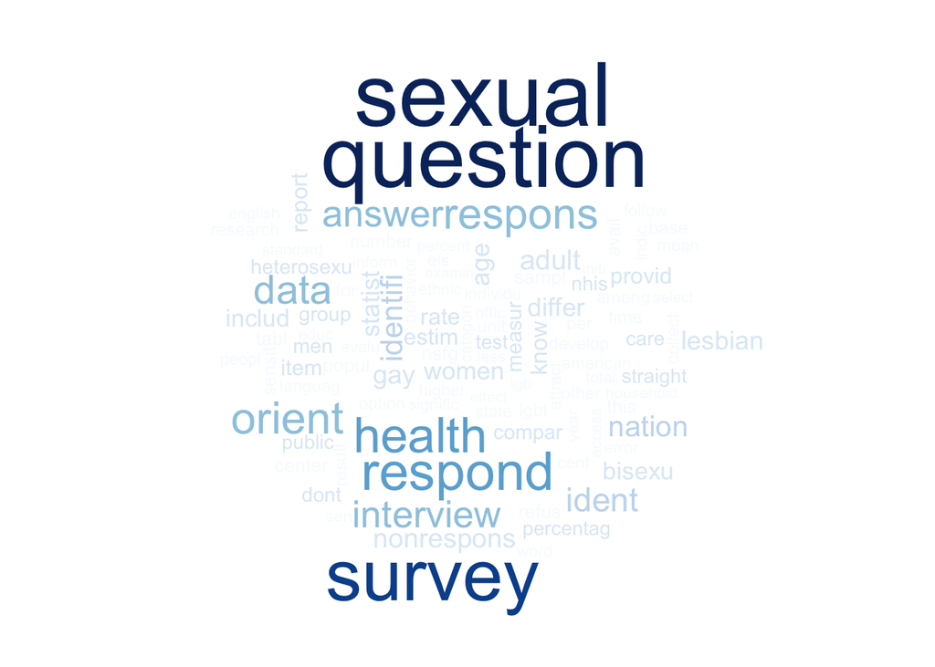

```r
termProbs <- data.frame()
for(i in 1:k){
  topic <- paste0("Topic ", i)
  temp <- termProbabilitiesByTopic[termProbabilitiesByTopic$Topic == topic,]
  temp <- temp[order(-temp$Probability),]
  termProbs <- rbind(termProbs, temp)
}
wordcloud((termProbs[termProbs$Topic == 'Topic 1','Term'][1:100]), (termProbs[termProbs$Topic == 'Topic 1','Probability'][1:100]), rot.per=.15, colors=brewer.pal(9, "Blues"))
```

#### Topic 2

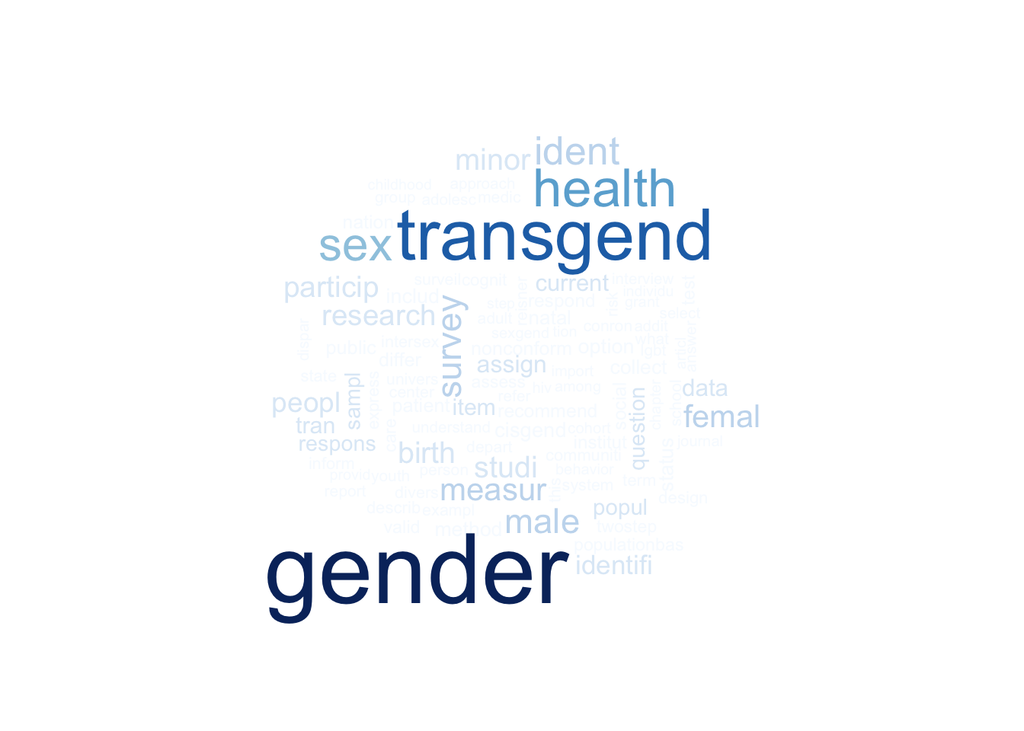

```r
wordcloud((termProbs[termProbs$Topic == 'Topic 2','Term'][1:100]), (termProbs[termProbs$Topic == 'Topic 2','Probability'][1:100]), rot.per=.15, colors=brewer.pal(9, "Blues"))
```

#### Topic 3

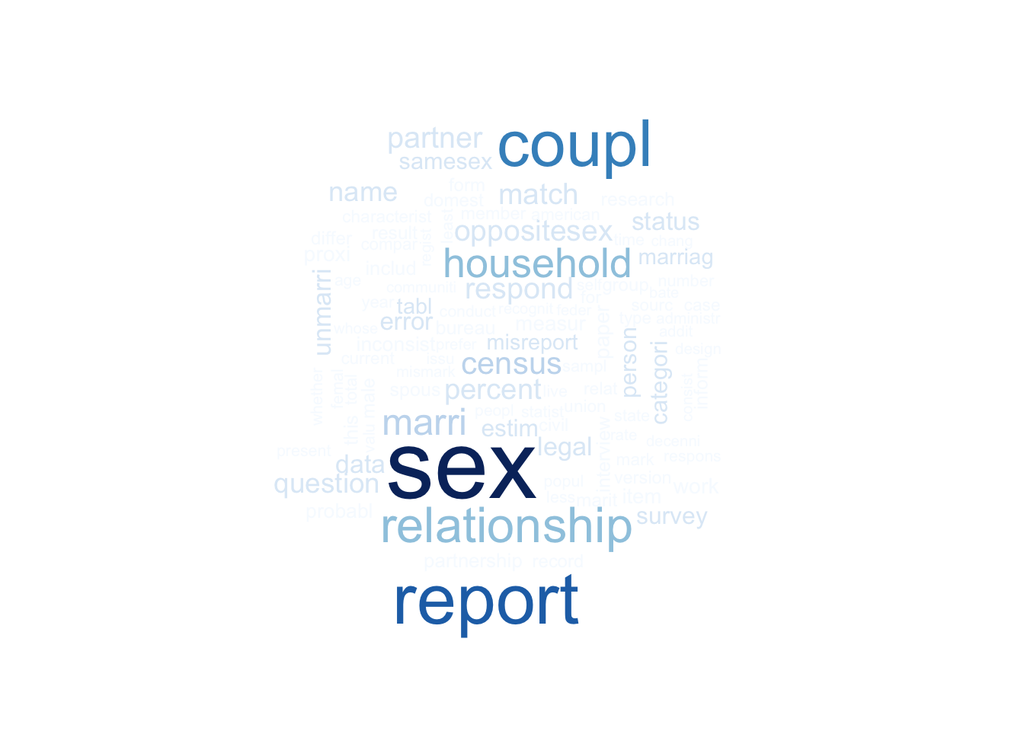

```r
wordcloud((termProbs[termProbs$Topic == 'Topic 3','Term'][1:100]), (termProbs[termProbs$Topic == 'Topic 3','Probability'][1:100]), rot.per=.15, colors=brewer.pal(9, "Blues"))
```

#### Topic 4

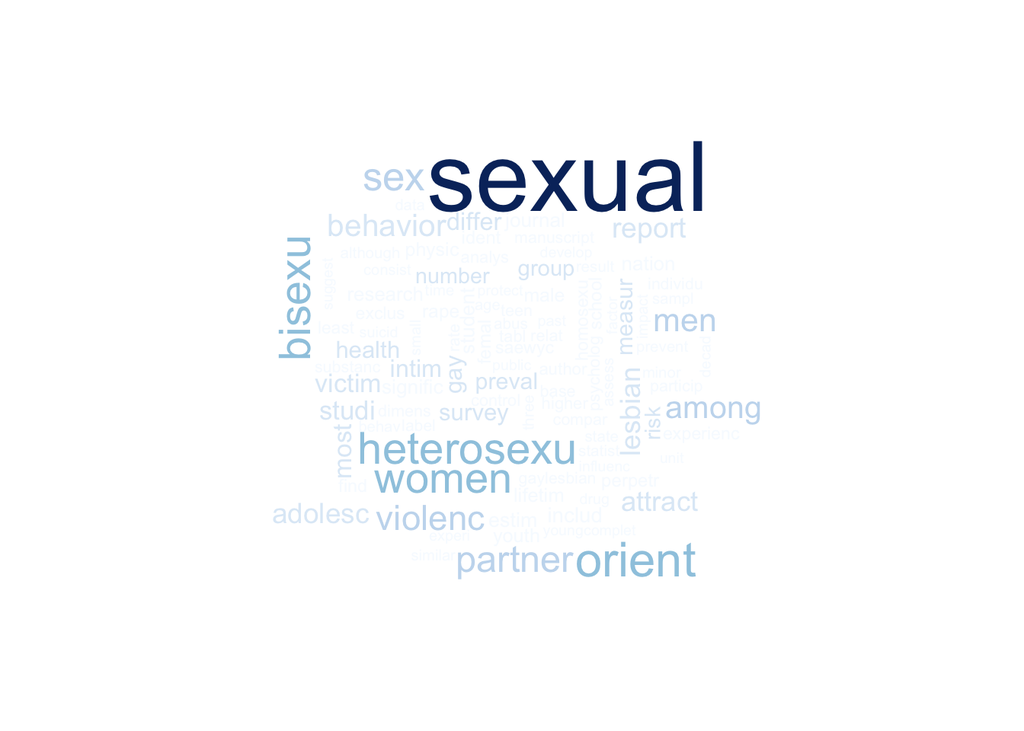

```r
wordcloud((termProbs[termProbs$Topic == 'Topic 4','Term'][1:100]), (termProbs[termProbs$Topic == 'Topic 4','Probability'][1:100]), rot.per=.15, colors=brewer.pal(9, "Blues"))
```

#### Topic 5

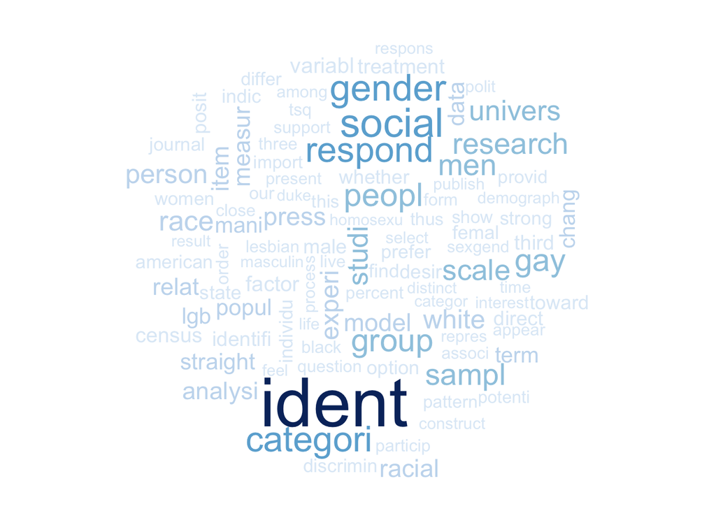

```r
wordcloud((termProbs[termProbs$Topic == 'Topic 5','Term'][1:100]), (termProbs[termProbs$Topic == 'Topic 5','Probability'][1:100]), rot.per=.15, colors=brewer.pal(9, "Blues"))
```

### Documents

Let’s look at the primary topics and compare them by frequency, i.e. how many documents have that primary topic assignment.

```r
# Docs per topic (primary topic only)
DocsToTopics <- as.data.frame(topics(ldaOut))
DocsToTopics$paper <- rownames(DocsToTopics)
names(DocsToTopics) <- c("topic", "paper")

primaryTopics <- as.data.frame(table(DocsToTopics$topic))
primaryTopics$topicName <- terms(ldaOut)
names(primaryTopics) <- c("Topic","Frequency","TopicName")
a <- list()
for (i in seq_len(nrow(primaryTopics))) {
  m <- primaryTopics[i, ]
  a[[i]] <- list(
    x = m$Topic,
    y =  m$Frequency,
    text = m$TopicName,
    xref = "x",
    yref = "y",
    showarrow = FALSE,
    arrowhead = 7,
    ax = 20,
    ay = -40
  )
}
plot_ly(primaryTopics, type = "scatter", x = Topic, y = Frequency, text = paste("Topic Name: ", TopicName), size = Frequency, mode = "markers") %>%
  layout(title ="Primary Topic Frequency") %>%
  layout(annotations = a)
```

[interactive chart not shown]